# Temperature and Gun Violence in New York City

2022-08-24

## Background

Temperature affects many of our day-to-day decisions. Consider the simple example of choosing an outfit. On a hot day, a person is more likely to wear shorts and less likely to wear a sweater but is complex behavior, like gun violence, also affected by temperature?

To determine if there is a relationship between temperature and gun violence, data on total shootings in New York City between 2006 - 2021 were analyzed.

The data were retrieved from from data.gov on August 24th, 2022.

```r
# Loading data into R, replacing blank values with NA, nys stands for New York Shooting
nys <- read.csv('https://data.cityofnewyork.us/api/views/833y-fsy8/rows.csv?accessType=DOWNLOAD', header = T, na.strings = c("","NA"))

# Printing summary of data
summary(nys)
##   INCIDENT_KEY        OCCUR_DATE         OCCUR_TIME            BORO
##  Min.   :  9953245   Length:25596       Length:25596       Length:25596
##  1st Qu.: 61593633   Class :character   Class :character   Class :character
##  Median : 86437258   Mode  :character   Mode  :character   Mode  :character
##  Mean   :112382648
##  3rd Qu.:166660833
##  Max.   :238490103
##
##     PRECINCT      JURISDICTION_CODE LOCATION_DESC      STATISTICAL_MURDER_FLAG
##  Min.   :  1.00   Min.   :0.0000    Length:25596       Length:25596
##  1st Qu.: 44.00   1st Qu.:0.0000    Class :character   Class :character
##  Median : 69.00   Median :0.0000    Mode  :character   Mode  :character
##  Mean   : 65.87   Mean   :0.3316
##  3rd Qu.: 81.00   3rd Qu.:0.0000
##  Max.   :123.00   Max.   :2.0000
##                   NA's   :2
##  PERP_AGE_GROUP       PERP_SEX          PERP_RACE         VIC_AGE_GROUP
##  Length:25596       Length:25596       Length:25596       Length:25596
##  Class :character   Class :character   Class :character   Class :character
##  Mode  :character   Mode  :character   Mode  :character   Mode  :character
##
##
##
##
##    VIC_SEX            VIC_RACE           X_COORD_CD        Y_COORD_CD
##  Length:25596       Length:25596       Min.   : 914928   Min.   :125757
##  Class :character   Class :character   1st Qu.:1000011   1st Qu.:182782
##  Mode  :character   Mode  :character   Median :1007715   Median :194038
##                                        Mean   :1009455   Mean   :207894
##                                        3rd Qu.:1016838   3rd Qu.:239429
##                                        Max.   :1066815   Max.   :271128
##
##     Latitude       Longitude        Lon_Lat
##  Min.   :40.51   Min.   :-74.25   Length:25596
##  1st Qu.:40.67   1st Qu.:-73.94   Class :character
##  Median :40.70   Median :-73.92   Mode  :character
##  Mean   :40.74   Mean   :-73.91
##  3rd Qu.:40.82   3rd Qu.:-73.88
##  Max.   :40.91   Max.   :-73.70
##
```

## Data Review and Wrangling

The output of the summary() function was used to identify variables to include/exclude from the analysis, and to ensure the data were in the appropriate format. After reviewing the output, 17 variables were removed from the data set. The variables were removed because they were outside the scope of the analysis (e.g., race of perpetrator, sex of victim) or had limited utility (e.g., longitude, latitude).

Date data were converted from a string variable to a date object, separated into different columns by day, month, and year, then bound to the original data frame using the bind_rows() function.

```r
# Removing excluded categories from data frame
# nys_rmvd stands for New York Shooting Data with variables removed
nys_rmvd <- subset(nys, select = -c(INCIDENT_KEY, JURISDICTION_CODE, X_COORD_CD,
                                    Y_COORD_CD, Latitude, Longitude, Lon_Lat,
                                    PERP_RACE, PERP_SEX, PRECINCT,
                                    PERP_AGE_GROUP, LOCATION_DESC, OCCUR_TIME,
                                    STATISTICAL_MURDER_FLAG, VIC_AGE_GROUP,
                                    VIC_SEX, VIC_RACE))

# Changing format of date
nys_rmvd$OCCUR_DATE <- as.POSIXct(nys_rmvd$OCCUR_DATE, format = "%m/%d/%Y")

# Creating a new data frame with seperated date data
df <- nys_rmvd %>%
  dplyr::mutate(YEAR = lubridate::year(OCCUR_DATE),
                MONTH = lubridate::month(OCCUR_DATE),
                DAY = lubridate::day(OCCUR_DATE))

# Binding two data frames
nys_mod <- bind_rows(df, nys_rmvd)

# Removing old date data
nys_mod <- subset(nys_mod, select = -c(OCCUR_DATE))
```

The data were then piped into the count() function to determine the total shootings per month. Data scored as NA (i.e., not associated with a month) were not included in the analysis and were removed from the data frame.

Data on the monthly average temperature were not included in the original data set; therefore, they were retrieved from an external source. Monthly averages from 1991 to 2020 were retrieved from Current Results and manually entered into R. The [data](https://www.currentresults.com/Weather/New-York/Places/new-york-city-temperatures-by-month-average.php) can be accessed using the hyper-linked text.

After the data were manually entered into an R vector, they were attached to a data frame containing the total number of shootings organized by month. The new data frame was used to generate scatter plots and build simple linear regression models.

```r
# Data frame with total shootings organized by month
nys_count <- nys_mod %>% count(MONTH)

# Removing NAs from data frame
nys_count <- nys_count[1:12,]

# Average high temperature for NYC by month
average_high <- c(39, 42, 50, 63, 73, 80, 86, 84, 78, 66, 54, 45)
average_low <- c(27, 29, 35, 46, 56, 64, 71, 69, 63, 53, 41, 35)

# Adding average high temperature to data frame
nys_count$average_high <- average_high
nys_count$average_low <- average_low
```

## Analysis

### Scatter Plots

The nys_count data frame and ggplot2 package were used to create two scatter plots. The purpose of creating the scatter plots was to determine if there was a correlation between temperature and total number of shootings.

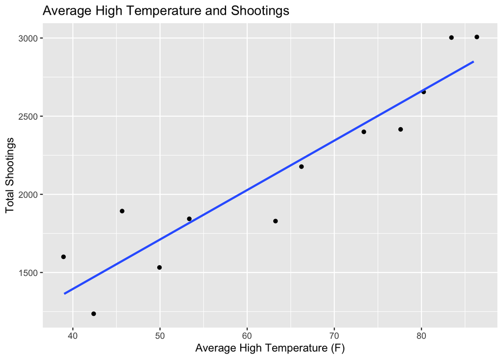

```r
# Scatter plot for average high temperature and total shootings
ggplot(data = nys_count, mapping = aes(x = average_high, y = n)) +
  geom_jitter() +
  geom_smooth(method = lm, se = F) +
  ylab("Total Shootings") +
  xlab("Average High Temperature (F)") +
  ggtitle("Average High Temperature and Shootings")
```

The data displayed above indicate a positive correlation between average high temperature and total shootings.

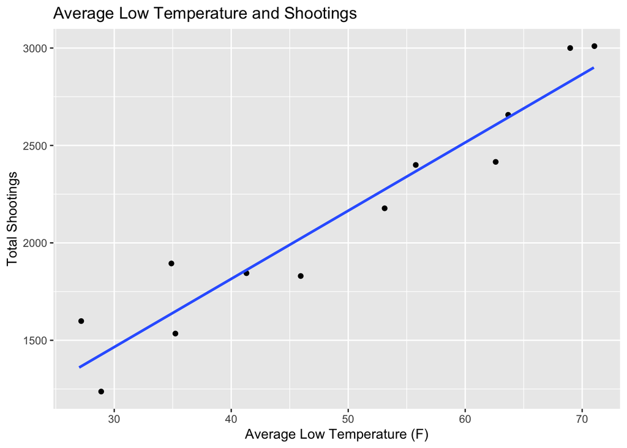

```r
# Scatter plot for average low temperature and total shootings
ggplot(data = nys_count, mapping = aes(x = average_low, y = n)) +
  geom_jitter() +
  geom_smooth(method = lm, se = F) +
  ylab("Total Shootings") +
  xlab("Average Low Temperature (F)") +
  ggtitle("Average Low Temperature and Shootings")
```

Similar to the scatter plot examining average high temperature and total shootings, the scatter plot for average low temperature and total shootings also show a positive correlation.

### Linear Models

```r
# Linear model
linear_mod <- lm(average_high ~ n, data = nys_count)

# Summary of linear model
summary(linear_mod)
```

```
##
## Call:
## lm(formula = average_high ~ n, data = nys_count)
##
## Residuals:
##     Min      1Q  Median      3Q     Max
## -11.708  -2.069   1.808   3.365   8.122
##
## Coefficients:
##             Estimate Std. Error t value Pr(>|t|)
## (Intercept) 4.202113   7.235995   0.581    0.574
## n           0.027722   0.003285   8.439 7.35e-06 ***
## ---
## Signif. codes:  0 '***' 0.001 '**' 0.01 '*' 0.05 '.' 0.1 ' ' 1
##
## Residual standard error: 6.26 on 10 degrees of freedom
## Multiple R-squared:  0.8769, Adjusted R-squared:  0.8646
## F-statistic: 71.22 on 1 and 10 DF,  p-value: 7.351e-06
```

The summary output indicates that average high temperature accounts for 86.46% of variance in the data.

```r
# Linear model
linear_mod <- lm(average_low ~ n, data = nys_count)

# Summary of linear model
summary(linear_mod)
```

```
##
## Call:
## lm(formula = average_low ~ n, data = nys_count)
##
## Residuals:
##     Min      1Q  Median      3Q     Max
## -8.1188 -1.4885  0.5415  2.9339  6.5021
##
## Coefficients:
##              Estimate Std. Error t value Pr(>|t|)
## (Intercept) -6.800901   5.497538  -1.237    0.244
## n            0.026200   0.002496  10.498 1.02e-06 ***
## ---
## Signif. codes:  0 '***' 0.001 '**' 0.01 '*' 0.05 '.' 0.1 ' ' 1
##
## Residual standard error: 4.756 on 10 degrees of freedom
## Multiple R-squared:  0.9168, Adjusted R-squared:  0.9085
## F-statistic: 110.2 on 1 and 10 DF,  p-value: 1.016e-06
```

The summary output indicates that average low temperature accounts for 90.85% of variance in the data.

## Discussion

Based on the results of the analysis, there appears to be a relationship between temperature and gun violence. Both scatter plots indicate a positive correlation between temperature and total shootings, and both models account for a large amount of the variance in the data.

### How the Analysis Can Be Used

The information from the analysis might be useful to law enforcement agencies and other stakeholder groups in New York City. For instance, it can inform when to allocate limited resources (e.g., access to indoor activities with air conditioning).

### Limitations

Although the data from this analysis could be used to address gun violence, there are at least two limitations that affect its utility. First, the analysis used monthly averages that were aggregated across several years, some of which were before 2006. Second, the analysis did not identify areas (e.g., public housing) associated with gun violence. Ideally, future iterations of this project will account for the limitations of the analysis.

### Potential Biases

To minimize bias, variables involving race, age, and sex were not included in the analysis; however, it may have been affected by other sources of bias. Specifically, the researcher’s previous experience may have influenced the type of models used (i.e., selection of simple linear regression).